[OHI British Columbia](http://www.ohibc.org/) | [OHI Science](http://ohi-science.org) | [Citation policy](https://github.com/OHI-Science/ohiprep/releases)

# OHIBC: Sea Level Rise Pressure layers prep

Compiled on Fri Aug 18 10:31:13 2017 by ohara

# 1 Summary

There are two parts to creating this layer:

1. Data prep to get raw data into the correct format:
   - If necessary, read .nc.gz files from aviso: ftp://ftp.aviso.altimetry.fr/global/delayed-time/grids/climatology/monthly_mean/
   - unzip .gz files and then delete .gz
   - Read monthly mean sea level data as rasters
2. Creating the pressure layers for OHI Global:
   - Clip all monthly rasters to the coast using a 3 nautical mile offshore buffer
   - Calculate annual mean sea level anomaly rasters from monthly data
   - Determine a reference point as the 99.99th quantile of the data across all years (1993 - 2015)
   - Rescale values from 0 to 1 using the reference point
   - Set to zero all negative values, indicating decreases in mean sea level
   - Resample raster to ~ 1km2 and reproject to Molleweide

This process is completed within the Global OHI 2017 prep script.

For OHIBC, we modify the OHI 2017 script to process the data within the BC region, in BC Albers projection, using a 1000 meter raster of the 3 nautical mile buffer.

# 2 Data

The raw data are monthly mean sea level anomalies, in meters. The anomalies are calculated using a reference period of 1993 - 2012. The anomalies represent a cumulative anomaly (sea level rise over reference) rather than an instantaneous anomaly (rate of sea level rise).

- **Reference**: The altimeter products were produced and distributed by Aviso (http://www.aviso.altimetry.fr/), as part of the Ssalto ground processing segment. [AVISO MSLA heights, monthly means](http://www.aviso.altimetry.fr/en/data/products/sea-surface-height-products/global/msla-mean-climatology.html)
- **Downloaded**: March 18, 2016; August 1, 2017 (for 2016 data)
- **Description**: Monthly mean sea level anomaly (meters above mean sea level)
- **Native data resolution**: 0.25 degree grid cells
- **Time range**: January 1993 - December 2016
- **Format**: NetCDF

# 3 Methods

## 3.1 Prepare BC sea level rise rasters

### 3.1.1 Clip raw monthly sea level anomaly data to BC extents

Here we rasterize the NetCDF files, crop to BC extents, reproject into BC Albers, and mask to just coastal cells.

The raw monthly data looks like this:

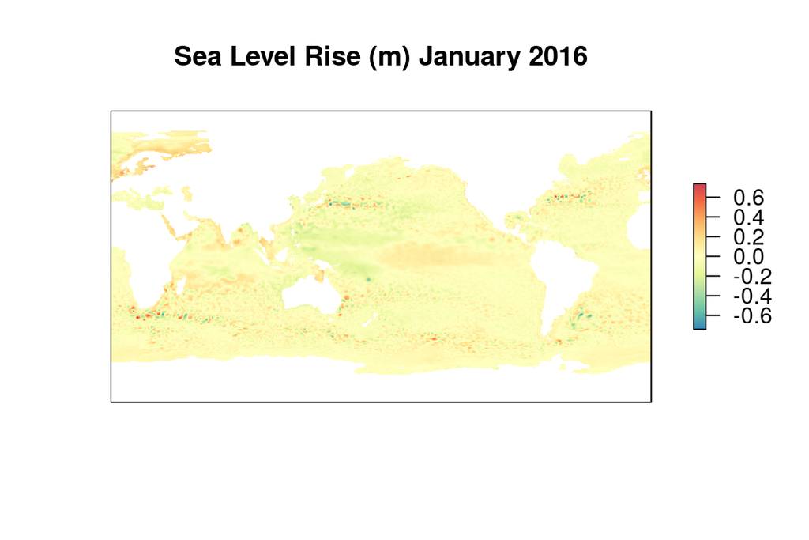

The function `process_months_bc` performs these steps:

1. Rasterize each monthly NetCDF file
2. Rotate each raster so that the Atlantic Ocean is centered in the raster
3. Crop the raster to the extents of British Columbia (based on OHIBC regions extent)
4. Reproject the result to BC Albers at 1000 m resolution.

The output is saved in the folder `git-annex/bcprep/_pressures/v2017/slr_rasts/msla_monthly_bc`.

### 3.1.2 Aggregate monthly mean sea level anomalies to annual

Annual mean sea level anomaly rasters are calculated from the monthly data.

### 3.1.3 Animate SLR annual mean rasters

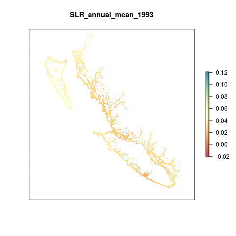

### 3.1.4 Determine reference Point

The reference point is the 99.99th quantile of the entire data distribution from 1993 - 2016. Rather than the [same reference point](https://github.com/OHI-Science/ohiprep/blob/master/globalprep/supplementary_information/v2016/reference_points_pressures.csv) that was used in previous global assessments: 0.246225 m, instead we will use the 99.99th quantile of the BC-specific data distribution across all months (prior to taking mean).

The 99.99%ile of all points (not just positive points) within the 3nm buffer of British Columbia is 0.2951197. This will be our reference point for rescaling SLR pressure

### 3.1.5 Rescale annual SL anomalies from 0-1

Each annual raster is recaled from 0 to 1 using the reference point. If a value is greater than the reference point, it is automatically given a value of 1. These final files are saved on Github.

## 3.2 Calculate mean pressures per region

From the clipped, reprojected, masked, and rescaled annual sea level anomalies, we now determine the mean value for each OHIBC region.

For each year, pull in the pressure raster and run zonal stats to find mean pressure in each region for each year. Values are smoothed using a rolling 5-year mean (current plus prior 4 years).

|  | rgn_id | year | prs_raw | pressure |
| --- | --- | --- | --- | --- |
| 1 | 1 | 1993 | 0.120643585506576 |  |
| 2 | 2 | 1993 | 0.157707337108357 |  |
| 3 | 3 | 1993 | 0.0899052379457057 |  |
| 4 | 4 | 1993 | 0.0959150683723012 |  |
| 5 | 5 | 1993 | 0.0948550530286797 |  |
| 6 | 6 | 1993 | 0.104141803269146 |  |
| 7 | 8 | 1993 | 0.0949222316168599 |  |
| 8 | 1 | 1994 | 0.0459900797025332 |  |
| 9 | 2 | 1994 | 0.0502567823162947 |  |
| 10 | 3 | 1994 | 0.0629463974791838 |  |

[output cut: 158 more lines]

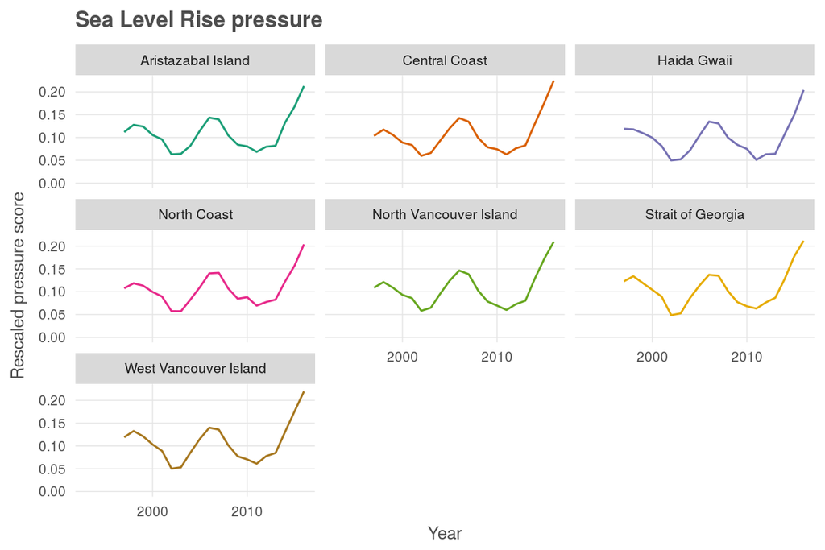

# 4 Provenance

- *Run ID: 4 (a1f6335); run tag: “standard run”*
- *Run elapsed time: 96.398 seconds; run memory usage: 9775.3 MB*
- *System info:*
  - *System: Linux, Release: 4.4.0-57-generic. Machine: x86_64. User: ohara.*
  - *R version: R version 3.4.1 (2017-06-30), Platform: x86_64-pc-linux-gnu, Running under: Ubuntu 14.04.5 LTS.*
  - *Attached base packages: stats, graphics, grDevices, utils, datasets, methods, base*
  - *Other attached packages: bindrcpp_0.2, provRmd_0.1.1, stringr_1.2.0, RColorBrewer_1.1-2, dplyr_0.7.2, purrr_0.2.2, readr_1.1.0, tidyr_0.6.3, tibble_1.3.3, ggplot2_2.2.1.9000, tidyverse_1.1.1, raster_2.5-8, rgdal_1.2-8, sp_1.2-5*

[figure not shown]

| sequence | file_name | parent_chunk | file_dir | filetype | uncomm_chgs | commit_hash_short |
| --- | --- | --- | --- | --- | --- | --- |
| 0 | pressures_slr_prep.Rmd | unnamed-chunk-1 | ~/github/ohibc/prep/_pressures/v2017 | parent_script | True | 17d14a6 |
| 0 | pressures_slr_prep.Rmd#animate_slr_means | animate_slr_means | ~/github/ohibc/prep/_pressures/v2017 | parent_chunk | True | 17d14a6 |
| 0 | pressures_slr_prep.Rmd#crop | crop | ~/github/ohibc/prep/_pressures/v2017 | parent_chunk | True | 17d14a6 |
| 0 | pressures_slr_prep.Rmd#get_mean_pressures | get_mean_pressures | ~/github/ohibc/prep/_pressures/v2017 | parent_chunk | True | 17d14a6 |
| 0 | pressures_slr_prep.Rmd#plot_pressures | plot_pressures | ~/github/ohibc/prep/_pressures/v2017 | parent_chunk | True | 17d14a6 |
| 0 | pressures_slr_prep.Rmd#plot_raw | plot_raw | ~/github/ohibc/prep/_pressures/v2017 | parent_chunk | True | 17d14a6 |
| 0 | pressures_slr_prep.Rmd#rescale | rescale | ~/github/ohibc/prep/_pressures/v2017 | parent_chunk | True | 17d14a6 |
| 0 | pressures_slr_prep.Rmd#setup | setup | ~/github/ohibc/prep/_pressures/v2017 | parent_chunk | True | 17d14a6 |
| 0 | pressures_slr_prep.Rmd#unnamed-chunk-1 | unnamed-chunk-1 | ~/github/ohibc/prep/_pressures/v2017 | parent_chunk | True | 17d14a6 |
| 1 | pressures_lyr_fxns.R | setup | ~/github/ohibc/prep/_pressures/v2017 | sourced_script | False | abc9d05 |

[output cut: 79 more lines]